# Assignment7

Dev Amin, Prisha Shah & Manan Patel

2025-10-30

```r
library(ggplot2)
library(dplyr)
# loading datasets
NOAAnew <- read.csv("NOAAnew.csv", check.names = FALSE)
NOAAnewA <- read.csv("NOAAnewA.csv", check.names = FALSE)

# defining helper functions
scale_year <- function(y) (y - 1980) / 10
engineer_features <- function(df_raw) {
  out <- data.frame(
    year        = scale_year(as.numeric(df_raw$year)),
    X.disaster  = as.numeric(df_raw$X.disaster),
    delta.temp  = as.numeric(df_raw$delta.temp)
  )
  out[["NOAA0$year^2"]]                  <- out$year^2
  out[["NOAA0$delta.temp^2"]]            <- out$delta.temp^2
  out[["NOAA0$year * NOAA0$delta.temp"]] <- out$year * out$delta.temp
  out
}

# fixing blank column names
namesA <- colnames(NOAAnewA)
if (any(is.na(namesA) | namesA == "")) {
  namesA[is.na(namesA) | namesA == ""] <- "Unnamed: 0"
  colnames(NOAAnewA) <- namesA
}

# building NOAAnewB with missing years
last_scaled <- suppressWarnings(max(as.numeric(NOAAnewA$year), na.rm = TRUE))
approx_last_year <- if (is.finite(last_scaled)) as.integer(round(last_scaled * 10 + 1980)) else 1980
extra_raw <- NOAAnew %>% filter(year > approx_last_year)
extra_feat <- if (nrow(extra_raw) > 0) engineer_features(extra_raw) else extra_raw

if (nrow(extra_feat) > 0) {
  extra_filled <- as.data.frame(matrix(NA, nrow = nrow(extra_feat), ncol = ncol(NOAAnewA)))
  colnames(extra_filled) <- colnames(NOAAnewA)
  common <- intersect(colnames(NOAAnewA), colnames(extra_feat))
  for (nm in common) extra_filled[[nm]] <- extra_feat[[nm]]
  NOAAnewB <- dplyr::bind_rows(NOAAnewA, extra_filled)
} else {
  NOAAnewB <- NOAAnewA
}

if ("Unnamed: 0" %in% names(NOAAnewB)) {
  NOAAnewB[["Unnamed: 0"]] <- seq_len(nrow(NOAAnewB))
}
NOAAnewB[is.na(NOAAnewB)] <- 0
write.csv(NOAAnewB, "NOAAnewB.csv", row.names = FALSE)
cat("saving NOAAnewB.csv with", nrow(NOAAnewB), "rows")
```

```
## saving NOAAnewB.csv with 45 rows
```

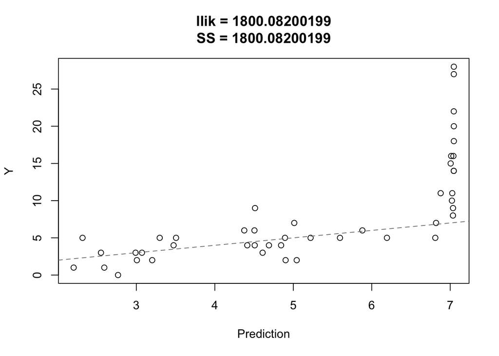

```r
# defining neural net functions
my.logistic <- function(z) exp(z) / (1 + exp(z))

my.eval1.nnet.ml <- function(Xrow, w0, hidden, output = "linear", num.layers = 2) {
  p <- length(Xrow)
  n_w1 <- p * hidden
  W1   <- matrix(w0[1:n_w1], p, hidden)
  wrem <- w0[-(1:n_w1)]
  z <- drop(t(Xrow) %*% W1)
  z <- my.logistic(z)
  if (num.layers > 1) {
    for (i in 2:num.layers) {
      n_wh <- hidden * hidden
      Wk   <- matrix(wrem[1:n_wh], hidden, hidden)
      wrem <- wrem[-(1:n_wh)]
      z <- my.logistic(drop(z %*% Wk))
    }
  }
  w_out <- wrem
  out <- sum(w_out * z)
  if (output == "binary") out <- my.logistic(out)
  out
}

my.eval2.nnet.ml <- function(w0, X, Y, hidden, output = "linear", num.layers = 2, lambda = 0.003) {
  zfun <- function(vrow) my.eval1.nnet.ml(vrow, w0, hidden, output, num.layers)
  pred <- apply(X, 1, zfun)
  ss   <- sum((pred - Y)^2) + lambda * sum(w0^2)
  list(llik = ss, pred = pred, y = Y)
}

my.neuralnet.multilayer <- function(X1, Y, hidden = 4, output = "linear",
                                    num.layers = 2, lambda = 0.003) {
  X <- cbind(1, X1)
  p <- ncol(X)
  n_w1    <- p * hidden
  n_whid  <- (num.layers - 1) * (hidden * hidden)
  n_wout  <- hidden
  n_total <- n_w1 + n_whid + n_wout
  set.seed(123)
  w0 <- runif(n_total, min = -0.1, max = 0.1)
  obj <- function(w) {
    val <- my.eval2.nnet.ml(w, X, Y, hidden, output, num.layers, lambda)$llik
    if (!is.finite(val)) return(Inf)
    val
  }
  opt <- optim(w0, obj, method = "L-BFGS-B",
               lower = rep(-2, n_total), upper = rep(2, n_total))
  ev  <- my.eval2.nnet.ml(opt$par, X, Y, hidden, output, num.layers, lambda)
  list(ss = opt$value, wfinal = opt$par, eval_result = ev, X = X)
}

my.greedy.neuralnet <- function(X0, Y, hidden = 4, output = "linear",
                                num.layers = 2, lambda = 0.003, trials = 15) {
  best <- my.neuralnet.multilayer(X0, Y, hidden, output, num.layers, lambda)
  if (trials > 1) {
    for (i in 2:trials) {
      cand <- my.neuralnet.multilayer(X0, Y, hidden, output, num.layers, lambda)
      if (cand$ss < best$ss) best <- cand
    }
  }
  with(best$eval_result, {
    plot(pred, y,
         xlab = "Prediction", ylab = "Y")
    title(main = paste0("llik = ", signif(llik, 12), "\nSS = ", signif(best$ss, 12)))
    abline(0, 1, lty = 2, col = "gray50")
  })
  best
}

# preparing X and Y
stopifnot("X.disaster" %in% names(NOAAnewB))
feature_cols <- setdiff(colnames(NOAAnewB), c("Unnamed: 0", "X.disaster"))
Xmat <- as.matrix(NOAAnewB[, feature_cols, drop = FALSE])
yvec <- as.numeric(NOAAnewB$X.disaster)

# running greedy NN
set.seed(123)
best_model <- my.greedy.neuralnet(
  X0         = Xmat,
  Y          = yvec,
  hidden     = 4,
  output     = "linear",
  num.layers = 2,
  lambda     = 0.003,
  trials     = 15
)
```

```r
# printing results like PDF
cat("$ss")
```

```r
print(best_model$ss)
```

```
## [1] 1800.082
```

```r
cat("$wfinal")
```

```r
print(best_model$wfinal)
```

```
##  [1]  2.0000000  2.0000000  2.0000000 -1.7977515  1.4567479  1.9066061
##  [7] -0.7268344  0.2597708  2.0000000 -2.0000000  1.9958257  1.2733243
## [13]  1.5774680 -0.5462167 -2.0000000  2.0000000 -1.5187292 -1.3208320
## [19]  2.0000000  2.0000000  2.0000000 -1.8109503  1.3658157  1.9808886
## [25] -1.7879261 -1.6356931  2.0000000 -2.0000000 -0.1555991 -2.0000000
## [31]  2.0000000 -0.3484018 -0.1217701 -2.0000000  2.0000000 -0.3954865
## [37] -0.7673806 -1.8167165  2.0000000 -1.0837349  2.0000000  2.0000000
## [43]  2.0000000  2.0000000
```

```r
cat("$eval_result")
```

```r
cat("## $eval_result$llik")
```

```
## ## $eval_result$llik
```

```r
print(best_model$eval_result$llik)
```

```
## [1] 1800.082
```

```r
cat("$eval_result$pred")
```

```
## $eval_result$pred
```

```r
print(best_model$eval_result$pred)
```

```
##  [1] 2.549084 2.201089 2.990016 2.314392 3.006757 3.297864 3.201938 2.766445
##  [9] 2.591430 3.506011 3.071347 3.474640 4.375336 4.508533 4.505061 4.413705
## [17] 4.689855 4.609111 4.512552 4.894387 5.043849 4.902294 4.844755 5.012313
## [25] 5.595139 5.220546 5.880739 6.193576 6.878238 6.819862 6.809776 7.012471
## [33] 7.026198 7.035777 7.034965 7.021686 7.005686 7.040844 7.045570 7.044782
## [41] 7.045548 7.046343 7.046359 7.046146 7.046033
```

```r
cat("$eval_result$y")
```

```
## $eval_result$y
```

```r
print(best_model$eval_result$y)
```

```
##  [1]  3  1  3  5  2  5  2  0  1  5  3  4  6  4  6  4  4  3  9  5  2  2  4  7  5
## [26]  5  6  5 11  7  5 16 11  9  8 10 15 16 14 14 22 20 18 28 27
```

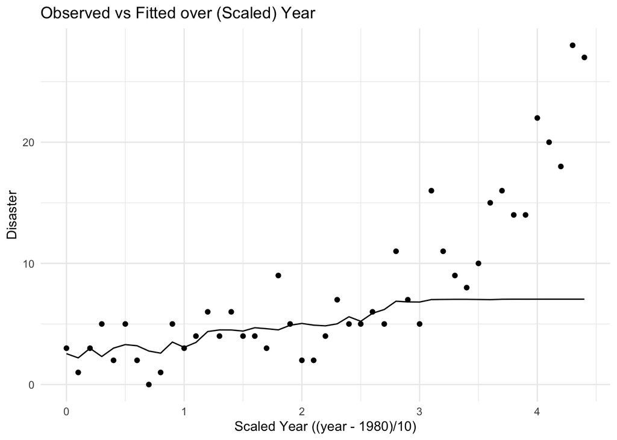

```r
# computing predictions and residuals
pred <- as.numeric(best_model$eval_result$pred)
res  <- yvec - pred

# plotting observed vs fitted
if ("year" %in% names(NOAAnewB)) {
  df_time <- data.frame(year = NOAAnewB$year, y = yvec, yhat = pred) %>% arrange(year)
  ggplot(df_time, aes(x = year, y = y)) +
    geom_point() +
    geom_line(aes(y = yhat)) +
    labs(title = "Observed vs Fitted over (Scaled) Year",
         x = "Scaled Year ((year - 1980)/10)", y = "Disaster") +
    theme_minimal()
}
```

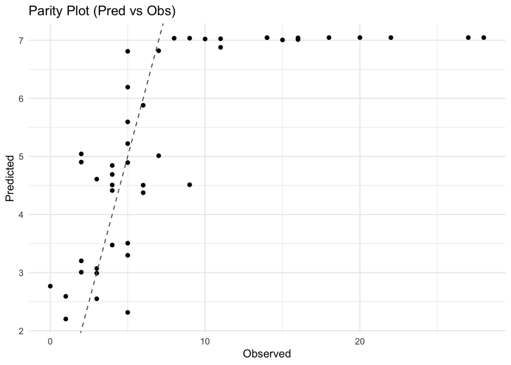

```r
# plotting parity plot
df_parity <- data.frame(obs = yvec, pred = pred)
ggplot(df_parity, aes(x = obs, y = pred)) +
  geom_point() +
  geom_abline(slope = 1, intercept = 0, linetype = 2, color = "gray40") +
  labs(title = "Parity Plot (Pred vs Obs)", x = "Observed", y = "Predicted") +
  theme_minimal()
```

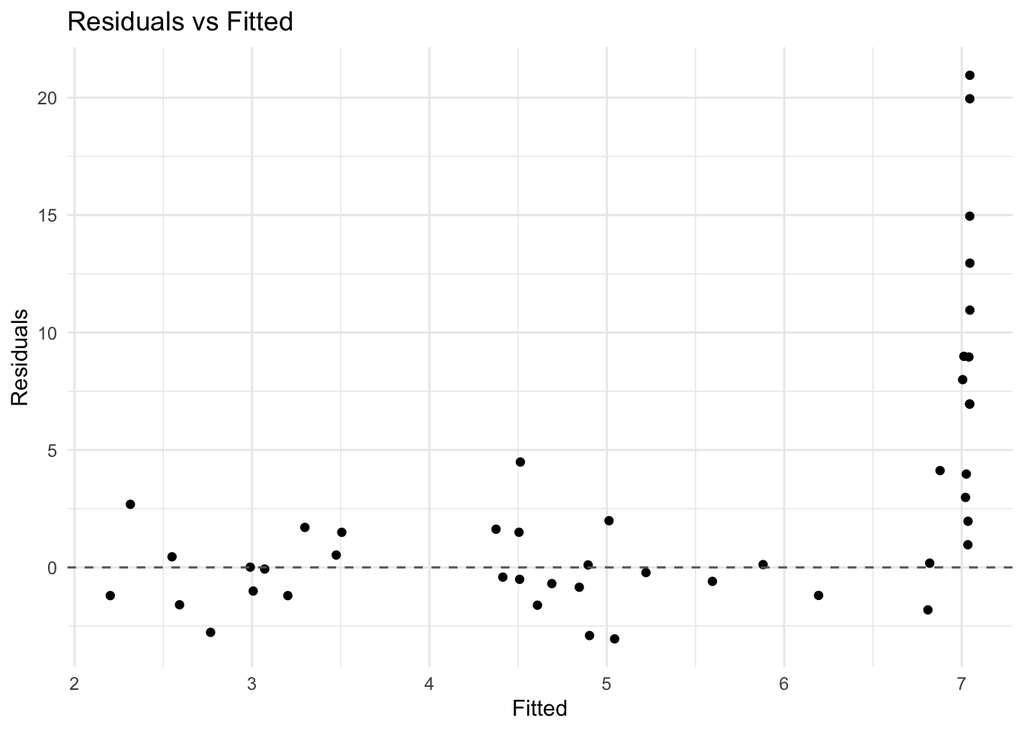

```r
# plotting residuals vs fitted
df_res <- data.frame(fitted = pred, resid = res)
ggplot(df_res, aes(x = fitted, y = resid)) +
  geom_point() +
  geom_hline(yintercept = 0, linetype = 2, color = "gray40") +
  labs(title = "Residuals vs Fitted", x = "Fitted", y = "Residuals") +
  theme_minimal()
```

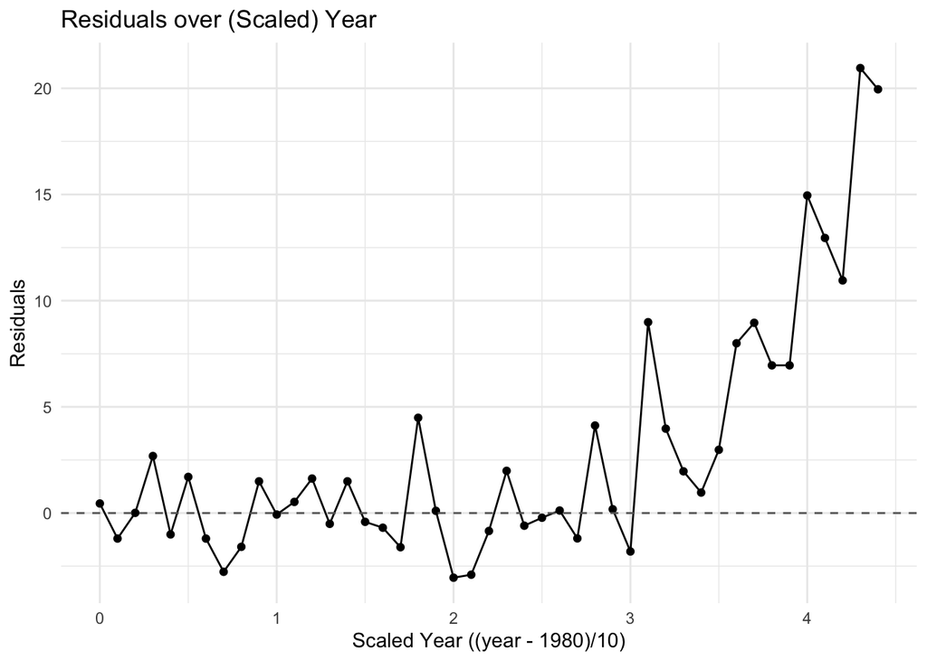

```r
# plotting residuals over time
if ("year" %in% names(NOAAnewB)) {
  df_res_time <- data.frame(year = NOAAnewB$year, resid = res)
  ggplot(df_res_time, aes(x = year, y = resid)) +
    geom_point() + geom_line() +
    geom_hline(yintercept = 0, linetype = 2, color = "gray40") +
    labs(title = "Residuals over (Scaled) Year",
         x = "Scaled Year ((year - 1980)/10)", y = "Residuals") +
    theme_minimal()
}
```

### Class 15 slide 3 comment : Single Hidden Layer

##### The code is creating and training a simple neural network with one hidden layer. The main function, my.neuralnet, starts by preparing the data, setting up random starting weights, and then using an optimization method to find the best weights that minimize the model’s error. The helper functions handle how the network makes predictions: my.eval1.nnet calculates the output for a single input by passing it through the hidden layer, and my.eval2.nnet applies this process to the entire dataset and measures how far the predictions are from the actual values. The my.logistic function adds the “activation” step that helps the network learn non-linear patterns. Overall, the code walks through the full process of building, training, and testing a small neural network from scratch

### Class 15 Slide 4 commnet: Multilayer with Regularization

##### The code builds a more advanced version of the neural network by adding multiple hidden layers and a regularization term to prevent overfitting. The main function, my.neuralnet.multilayer, prepares the data, initializes the weights for each layer, and uses optimization methods like BFGS or CG to minimize the total error. The helper functions handle how the data flows through the network: my.eval1.nnet.ml runs the forward pass through all hidden layers using the logistic activation function, and my.eval2.nnet.ml computes the overall error (loss) while also adding a penalty term (lambda * sum(w^2)) that discourages excessively large weights. The code ends by plotting predicted versus actual values to visualize model performance. In short, this version generalizes the single-hidden-layer network from the previous slide, allowing for deeper architectures and more stable learning through regularization